# Tema 6 Ejercicio completo final

Carla Romero Sansano

21 de noviembre de 2019

# EJEMPLO FINAL (con todo lo aprendido en el tema 6)

Vamos a utilizar HairEyeColor:

Vamos a llevar a cabo un análisis completo de un ejemplo con lo que hemos aprendido en esta lección y aprovecharemos para aprender algo nuevo.

El objeto de datos **HairEyeColor** que lleva predefinido R es una tabla de frecuencias absolutas de tres variables cualitativas: color de cabello (**Hair**), color de ojos (**Eye**) y sexo (**Sex**).

Vamos a extraer de esta tabla una tabla bidimensional de frecuencias absolutas de las variables **Eye** y **Hair**, sin distinguir según el sexo. La manera más sencilla de obtener esta tabla es sumando las subtablas de frecuencias para hombres y mujeres, y aplicando **as.table()** al resultado para transformarlo en una **table** por si no lo es.

## Juntar color de ojos y pelo sin distinguir por sexo

```r
ftable(HairEyeColor)
```

```
##             Sex Male Female
## Hair  Eye
## Black Brown       32     36
##       Blue        11      9
##       Hazel       10      5
##       Green        3      2
## Brown Brown       53     66
##       Blue        50     34
##       Hazel       25     29
##       Green       15     14
## Red   Brown       10     16
##       Blue        10      7
##       Hazel        7      7
##       Green        7      7
## Blond Brown        3      4
##       Blue        30     64
##       Hazel        5      5
##       Green        8      8
```

```r
male <- HairEyeColor[, ,"Male"] #Todos los colores de ojo y de pelo para hombres
female <- HairEyeColor[, , "Female"] #Todos los colores de ojo y pelo para mujeres
data <- as.table(male+female) #todos los datos juntos sin distinción de sexo
data
```

```
##        Eye
## Hair    Brown Blue Hazel Green
##   Black    68   20    15     5
##   Brown   119   84    54    29
##   Red      26   17    14    14
##   Blond     7   94    10    16
```

Vamos a traducir al castellano los nombres de las variables de esta tabla y de sus niveles.Esto lo podemos llevar a cabo en un solo paso con la función **dimnames()** que ya usamos sobre data frames. El resultado de aplicar esta función a una table es una **list** cuyas componentes son los niveles de cada variable.

```r
dimnames(HairEyeColor)
```

```
## $Hair
## [1] "Black" "Brown" "Red"   "Blond"
##
## $Eye
## [1] "Brown" "Blue"  "Hazel" "Green"
##
## $Sex
## [1] "Male"   "Female"
```

### Ejercicio. Redefinid dicha **list** para tener los niveles de los factores en castellano

#### Manipulación de datos

```r
dimnames(data) = list(
  Pelo = c("Negro", "Marron", "Pelirrojo", "Rubio"),
  Ojos = c("Marrones", "Azules", "Pardos", "Verdes")
)
data
```

```
##            Ojos
## Pelo        Marrones Azules Pardos Verdes
##   Negro           68     20     15      5
##   Marron         119     84     54     29
##   Pelirrojo       26     17     14     14
##   Rubio            7     94     10     16
```

### Ejercicio. Dibujad un diagrama de mosaico de esta tabla, para visualizar gráficamente sus entradas.

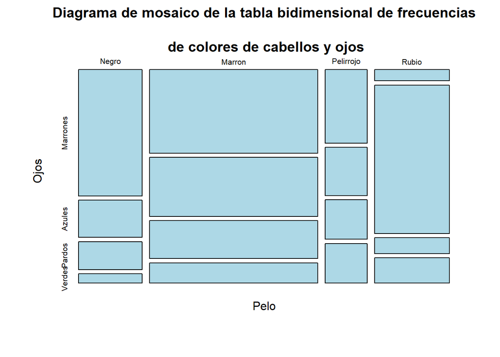

```r
plot(data, col = c("lightblue"), main = "Diagrama de mosaico de la tabla bidimensional de frecuencias
     \n de colores de cabellos y ojos")
```

### Ejercicio. Calcular el número total de individuos representados en esta tabla

#### Datos numéricos

```r
#Respuesta JuanGabriel:
sum(data)
```

```
## [1] 592
```

```r
?table
```

```
## starting httpd help server ... done
```

```r
summary(data)
```

```
## Number of cases in table: 592
## Number of factors: 2
## Test for independence of all factors:
##  Chisq = 138.29, df = 9, p-value = 2.325e-25
```

### Ejercicio. Tablas de frecuencias absolutas y relativas de cada variable

```r
#Los datos de OJOS están en las columnas
#Los datos de PELO están en las filas
colSums(data) #frecuencia absoluta ojps
```

```
## Marrones   Azules   Pardos   Verdes
##      220      215       93       64
```

```r
rowSums(data) #frecuencia absoluta pelo
```

```
##     Negro    Marron Pelirrojo     Rubio
##       108       286        71       127
```

```r
round(prop.table(colSums(data)), 3) #frecuencia relativa con 3 decimales ojos
```

```
## Marrones   Azules   Pardos   Verdes
##    0.372    0.363    0.157    0.108
```

```r
round(prop.table(rowSums(data)), 3) #frecuencia relativa con 3 decimales pelo
```

```
##     Negro    Marron Pelirrojo     Rubio
##     0.182     0.483     0.120     0.215
```

### Ejercicio. Representar las frecuencias relativas anteriores en sendos diagramas de barras

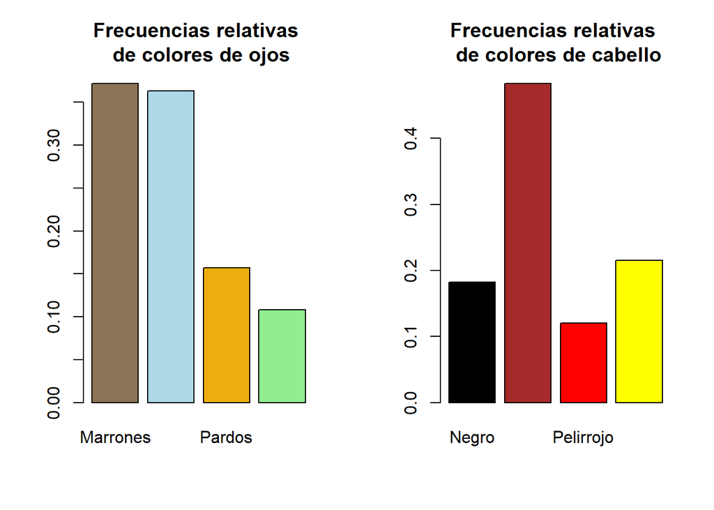

```r
par(mfrow=c(1,2))
barplot(round(prop.table(colSums(data)), 3), col = c("burlywood4", "lightblue", "darkgoldenrod2", "lightgreen"), main = "Frecuencias relativas \n de colores de ojos")
barplot(round(prop.table(rowSums(data)), 3), col = c("black", "brown", "red", "yellow"), main = "Frecuencias relativas \n de colores de cabello")
```